```python
import pandas as pd
import numpy as np
import time
import datetime
from sklearn.metrics import mean_squared_error, r2_score
#from sklearn.preprocessing import PolynomialFeatures
from datetime import datetime,timedelta
#from sklearn.metrics import mean_squared_error
from scipy.optimize import curve_fit
from scipy.optimize import fsolve
from sklearn import linear_model
import matplotlib.pyplot as plt
import simpy
import random
%matplotlib inline
```

# Modelos Matematico

```python
url = ('recuperados.csv')
df_n = pd.read_csv(url, sep=';')
df_n
```

|  | fecha | dia | total |
| --- | --- | --- | --- |
| 0 | 0 | 0 | 0 |
| 1 | 1 | 0 | 0 |
| 2 | 2 | 0 | 0 |
| 3 | 3 | 0 | 0 |
| 4 | 4 | 0 | 0 |
| ... | ... | ... | ... |
| 75 | 75 | 103 | 3536 |
| 76 | 76 | 0 | 3536 |
| 77 | 77 | 0 | 3536 |
| 78 | 78 | 0 | 3536 |
| 79 | 79 | 24 | 3560 |

80 rows × 3 columns

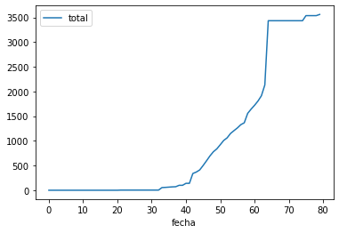

```python
df = df_n.loc[:,['fecha','total']]
df
df.plot(x ='fecha', y='total')
```

```python
x = list(df.iloc [:, 0]) # Fecha
y = list(df.iloc [:, 1]) # recuperados_total
#z = list(df.iloc [:, 2])#recuperados_total

print(y)
print(x)
```

```
[0, 0, 0, 0, 0, 0, 0, 0, 0, 0, 0, 0, 0, 0, 0, 0, 0, 0, 0, 0, 0, 3, 3, 3, 3, 3, 3, 3, 3, 3, 3, 3, 3, 54, 58, 63, 68, 71, 100, 100, 140, 140, 339, 368, 411, 501, 597, 696, 780, 838, 922, 1008, 1061, 1150, 1207, 1262, 1328, 1366, 1557, 1643, 1720, 1806, 1913, 2132, 3433, 3433, 3433, 3433, 3433, 3433, 3…
[0, 1, 2, 3, 4, 5, 6, 7, 8, 9, 10, 11, 12, 13, 14, 15, 16, 17, 18, 19, 20, 21, 22, 23, 24, 25, 26, 27, 28, 29, 30, 31, 32, 33, 34, 35, 36, 37, 38, 39, 40, 41, 42, 43, 44, 45, 46, 47, 48, 49, 50, 51, 52, 53, 54, 55, 56, 57, 58, 59, 60, 61, 62, 63, 64, 65, 66, 67, 68, 69, 70, 71, 72, 73, 74, 75, 76, 7…
```

```
Predicción en el día 86, es decir, 7 días: 13247 recuperados
Predicción en el día 109, es decir, 30 días: 274028 recuperados
```

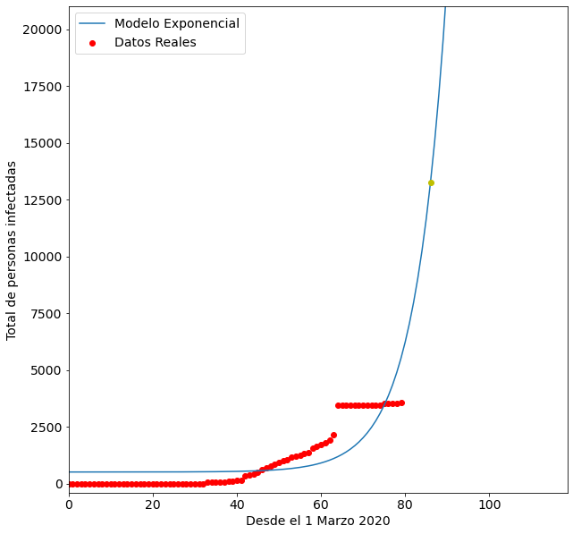

```python
def modelo_exponencial(x,a,b):
    return a+b*np.exp(b*x)

exp_fit = curve_fit(modelo_exponencial,x,y)

pred_x = list(range(0,max(x)+100))
plt.rcParams['figure.figsize'] = [10, 10]
plt.rc('font', size=14)


plt.scatter(x,y,label="Datos Reales",color="red")
# Predicted exponential curve
puntos=[modelo_exponencial(i,exp_fit[0][0],exp_fit[0][1]) for i in pred_x]
print ('Predicción en el día 86, es decir, 7 días:', int(puntos[86]), 'recuperados')
print ('Predicción en el día 109, es decir, 30 días:', int(puntos[109]), 'recuperados')

plt.plot(pred_x,puntos , label="Modelo Exponencial")
plt.legend()
plt.ylabel("Total de personas infectadas")
plt.xlabel("Desde el 1 Marzo 2020")
plt.ylim((-400,max(y)*5.9))
plt.xlim((min(x)*0.9,max(x)*1.5))
plt.plot(86,puntos[86], 'oy')
plt.plot(109,puntos[109], 'oy')
plt.show()
```

```
Predicción en el día 86, en 7 días: 5351 recuperados
Predicción en el día 109 en 30 días: 9759 recuperados
```

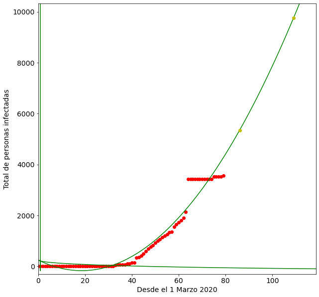

```python
#polinomial
from sklearn.linear_model import LinearRegression
from sklearn.preprocessing import PolynomialFeatures

pf = PolynomialFeatures(degree = 2)    # usaremos polinomios de grado 6
X = pf.fit_transform(np.array(x).reshape(-1, 1))

regresion_lineal = LinearRegression()

regresion_lineal.fit(X, y)



pred_x = list(range(0,max(x)+100))

puntos = pf.fit_transform(np.array(pred_x).reshape(-1, 1))
prediccion_entrenamiento = regresion_lineal.predict(puntos)
print ('Predicción en el día 86, en 7 días:', int(prediccion_entrenamiento[86]), 'recuperados')
print ('Predicción en el día 109 en 30 días:', int(prediccion_entrenamiento[109]), 'recuperados')


plt.plot(puntos, prediccion_entrenamiento, color='green')
plt.scatter(x,y,label="Datos Reales",color="red")
plt.ylim((-300,max(y)*2.9))
plt.xlim((min(x)*1.9,max(x)*1.5))
plt.xlabel("Desde el 1 Marzo 2020")
plt.ylabel("Total de personas infectadas")
plt.plot(86,prediccion_entrenamiento[86], 'oy')
plt.plot(109,prediccion_entrenamiento[109],'oy')

plt.show()
```

# Modelo Probabilistico

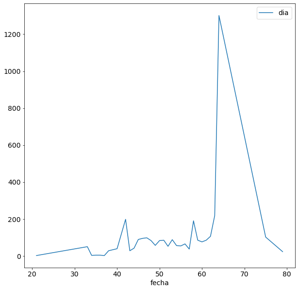

```python
url = ('recuperados.csv')
df = pd.read_csv(url, sep=';')
df = df.loc[:,['fecha','dia']]
df=df[df['dia']>0.0]
df
df.plot(x ='fecha', y='dia')
```

```python
filtro = df['dia'] # Filtro los datos que se empezo a tener casos
#Obtenemos la mediana
#print(filtro)
media = filtro.mean()
mediana = filtro.median()
print('mediana',mediana)
print('media', media)
```

```
mediana 66.0
media 107.87878787878788
```

```python
x = list(df_n.iloc [:, 0]) # Dias
y = list(df_n.iloc [:, 2]) # Total casos
print(y)
print(x)
```

```
[0, 0, 0, 0, 0, 0, 0, 0, 0, 0, 0, 0, 0, 0, 0, 0, 0, 0, 0, 0, 0, 3, 3, 3, 3, 3, 3, 3, 3, 3, 3, 3, 3, 54, 58, 63, 68, 71, 100, 100, 140, 140, 339, 368, 411, 501, 597, 696, 780, 838, 922, 1008, 1061, 1150, 1207, 1262, 1328, 1366, 1557, 1643, 1720, 1806, 1913, 2132, 3433, 3433, 3433, 3433, 3433, 3433, 3…
[0, 1, 2, 3, 4, 5, 6, 7, 8, 9, 10, 11, 12, 13, 14, 15, 16, 17, 18, 19, 20, 21, 22, 23, 24, 25, 26, 27, 28, 29, 30, 31, 32, 33, 34, 35, 36, 37, 38, 39, 40, 41, 42, 43, 44, 45, 46, 47, 48, 49, 50, 51, 52, 53, 54, 55, 56, 57, 58, 59, 60, 61, 62, 63, 64, 65, 66, 67, 68, 69, 70, 71, 72, 73, 74, 75, 76, 7…
```

```python
#Realizamos un ejemplo de prediccion
prediccion_siguiente = int(y[-1] + mediana)
print('siguientePrediccion: ', prediccion_siguiente)
```

```
siguientePrediccion:  3626
```

```
actual: 3560
cuantos recuperados más en una semana: 4022
```

[figure not shown]

```python
print('actual:',y[79])
for i in range(x[-1]+1, x[-1]+7):
    x.append(i)
    y.append(int(y[-1] + mediana))

print('cuantos recuperados más en una semana:',y[86])
plt.plot(x, y)
plt.show()
```

```
cuantos recuperados en 30 días: 5540
```

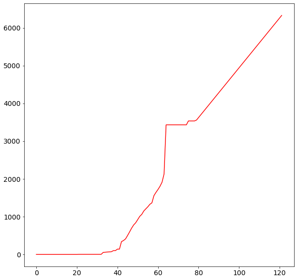

```python
for i in range(x[-1]+1, x[-1]+31):
    x.append(i)
    y.append(int(y[-1] + mediana))

print('cuantos recuperados en 30 días:',y[109])
plt.plot(x, y, color='r')
#plt.scatter(x,y)
plt.show()
```

# Laboral

```python
#PARAMETROS

#staticos
recuperadosPrediccion=9759
tCrecimiento=int(media)
simulacion=214
LABORATORIO=26


recuperados={}
desempleados={}
reinserccionA={}
reinserccionR={}
reinserccionH={}
reinserccionV={}
reinserccionRE={}

alimentaciones={}
retail={}
hoteles={}
viajes={}
restaurante={}
```

```python
class Laborar(object):

    def __init__(self, env, lab):
            self.env = env
            self.lab=lab
            self.lab = simpy.Resource(env, lab)

    def descansar(self, personas):
        yield self.env.timeout(random.randint(2,7))
        #print("Persona, con numero", personas, "termina la recuperacion  el dia:  ", int(self.env.now))

    def teletrabajo(self, personas):
        yield self.env.timeout(random.randint(5,14))
        #print("Persona, con numero", personas, "termina teletrabajo  el dia: ", int(self.env.now))

    def valoracion(self, personas):
        yield self.env.timeout(random.randint(3,7))
        #print("Persona, con numero", personas, "termina la valoracion  el dia: ", int(self.env.now))

    def laboratorios(self, personas):
        yield self.env.timeout(random.randint(5,15))
        #print("Persona, con numero", personas, "sale del laboratorio el dia : ", int(self.env.now))

    def trabajo(self, personas):
        yield self.env.timeout(random.randint(5,14))
        #print("Persona, con numero", personas, "termina la etapa de trabajo  el dia: ", int(self.env.now))
def llegada_persona(env, laborar, persona):
    llega=env.now
    puestos=random.randint(1,100)
    if(puestos<=70):
        tipoEmpleo=random.randint(1,5)
        if (tipoEmpleo==1):
            alimentaciones[env.now] = alimentaciones[env.now] + 1 if env.now in alimentaciones else  1
            laborar.descansar(persona)
            laborar.teletrabajo(persona)
            bandera=True
            with laborar.lab.request() as lab:
                dias_esperando = random.randint(5,15)
                requerimientolab = yield lab | env.timeout(dias_esperando)
                wait = env.now - llega
                if lab in requerimientolab:
                    yield env.process(laborar.laboratorios(persona))
                    estado = random.randint(1,100)
                    if (estado <= 70):
                        laborar.trabajo(persona)
                        bandera=False
                        recuperados[env.now] = recuperados[env.now] + 1 if env.now in recuperados else  1
                        reinserccionA[env.now] = reinserccionA[env.now] + 1 if env.now in reinserccionA else  1
                    else:
                        laborar.valoracion(persona)
                        bandera=True

                else:
                    alimentaciones[env.now] = alimentaciones[env.now] + 1 if env.now in alimentaciones else  1

        elif(tipoEmpleo==2):
            restaurante[env.now] = restaurante[env.now] + 1 if env.now in restaurante else  1

            laborar.descansar(persona)
            laborar.teletrabajo(persona)
            bandera=True
            with laborar.lab.request() as lab:
                dias_esperando = random.randint(5,15)
                requerimientolab = yield lab | env.timeout(dias_esperando)
                wait = env.now - llega
                if lab in requerimientolab:
                    yield env.process(laborar.laboratorios(persona))
                    estado = random.randint(1,100)
                    if (estado <= 70):
                        laborar.trabajo(persona)
                        bandera=False
                        recuperados[env.now] = recuperados[env.now] + 1 if env.now in recuperados else  1
                        reinserccionRE[env.now] = reinserccionRE[env.now] + 1 if env.now in reinserccionRE else  1

                    else:
                        laborar.valoracion(persona)
                        bandera=True

                else:
                    restaurante[env.now] = restaurante[env.now] + 1 if env.now in restaurante else  1

        elif(tipoEmpleo==3):
            retail[env.now] = retail[env.now] + 1 if env.now in retail else  1

            laborar.descansar(persona)
            laborar.teletrabajo(persona)
            bandera=True
            with laborar.lab.request() as lab:
                dias_esperando = random.randint(5,15)
                requerimientolab = yield lab | env.timeout(dias_esperando)
                wait = env.now - llega
                if lab in requerimientolab:
                    yield env.process(laborar.laboratorios(persona))
                    estado = random.randint(1,100)
                    if (estado <= 70):
                        laborar.trabajo(persona)
                        bandera=False
                        recuperados[env.now] = recuperados[env.now] + 1 if env.now in recuperados else  1
                        reinserccionR[env.now] = reinserccionR[env.now] + 1 if env.now in reinserccionR else  1
                    else:
                        laborar.valoracion(persona)
                        bandera=True

                else:
                    retail[env.now] = retail[env.now] + 1 if env.now in retail else  1

        elif(tipoEmpleo==4):
            hoteles[env.now] = hoteles[env.now] + 1 if env.now in hoteles else  1

            laborar.descansar(persona)
            laborar.teletrabajo(persona)
            bandera=True
            with laborar.lab.request() as lab:
                dias_esperando = random.randint(5,15)
                requerimientolab = yield lab | env.timeout(dias_esperando)
                wait = env.now - llega
                if lab in requerimientolab:
                    yield env.process(laborar.laboratorios(persona))
                    estado = random.randint(1,100)
                    if (estado <= 70):
                        laborar.trabajo(persona)
                        bandera=False
                        recuperados[env.now] = recuperados[env.now] + 1 if env.now in recuperados else  1
                        reinserccionH[env.now] = reinserccionH[env.now] + 1 if env.now in reinserccionH else  1
                    else:
                        laborar.valoracion(persona)
                        bandera=True

                else:
                    hoteles[env.now] = hoteles[env.now] + 1 if env.now in hoteles else  1

        elif(tipoEmpleo==5):
            viajes[env.now] = viajes[env.now] + 1 if env.now in viajes else  1

            laborar.descansar(persona)
            laborar.teletrabajo(persona)
            bandera=True
            with laborar.lab.request() as lab:
                dias_esperando = random.randint(5,15)
                requerimientolab = yield lab | env.timeout(dias_esperando)
                wait = env.now - llega
                if lab in requerimientolab:
                    yield env.process(laborar.laboratorios(persona))
                    estado = random.randint(1,100)
                    if (estado <= 70):
                        laborar.trabajo(persona)
                        bandera=False
                        recuperados[env.now] = recuperados[env.now] + 1 if env.now in recuperados else  1
                        reinserccionV[env.now] = reinserccionV[env.now] + 1 if env.now in reinserccionV else  1
                    else:
                        laborar.valoracion(persona)
                        bandera=True

                else:
                     viajes[env.now] = viajes[env.now] + 1 if env.now in viajes else  1

    else:
        desempleados[env.now] = desempleados[env.now] + 1 if env.now in desempleados else  1


def ejecutar(env, tasa_crecimiento, recuperados):
    laborar = Laborar(env,LABORATORIO)
    for i in range(recuperadosPrediccion):
        asignar_laborar(env, laborar, i)
    personas = recuperadosPrediccion
    while True:
        yield env.timeout(1)
        for i in range(tasa_crecimiento):
            personas += 1
            asignar_laborar(env, laborar, personas)


def asignar_laborar(env, laborar, personas):
    existente=1
    if (existente == 1):
        #print("Llega nueva persona", personas, " en el día ", env.now)
        env.process(llegada_persona(env, laborar, personas))

print("Trabajos")
env=simpy.Environment()
env.process(ejecutar(env,tCrecimiento,recuperadosPrediccion))
env.run(until=simulacion)
```

```
Trabajos
```

```python
alj=[]
rj=[]
hj=[]
vj=[]
rej=[]

alju=[]
rju=[]
hju=[]
vju=[]
reju=[]

ala=[]
ra=[]
ha=[]
va=[]
rea=[]

als=[]
rs=[]
hs=[]
vs=[]
res=[]

alo=[]
ro=[]
ho=[]
vo=[]
reo=[]

aln=[]
rn=[]
hn=[]
vn=[]
ren=[]

ald=[]
rd=[]
hd=[]
vd=[]
red=[]
a=0
for i in reinserccionA.values():
    if(a>=0 and a<30):
        alj.append(i)

    elif(a>=30 and a<60):
        alju.append(i)

    elif(a>=60 and a<90):
        ala.append(i)

    elif(a>=90 and a<120):
        als.append(i)
    elif(a>=120 and a<150):
        alo.append(i)
    elif(a>=150 and a<180):
        aln.append(i)
    elif(a>=180):
        ald.append(i)
    a+=1

a=0
for i in reinserccionR.values():
    if(a>=0 and a<30):
        rj.append(i)

    elif(a>=30 and a<60):
        rju.append(i)

    elif(a>=60 and a<90):
        ra.append(i)

    elif(a>=90 and a<120):
        rs.append(i)
    elif(a>=120 and a<150):
        ro.append(i)
    elif(a>=150 and a<180):
        rn.append(i)
    elif(a>=180):
        rd.append(i)
    a+=1

a=0
for i in reinserccionH.values():
    if(a>=0 and a<30):
        hj.append(i)

    elif(a>=30 and a<60):
        hju.append(i)

    elif(a>=60 and a<90):
        ha.append(i)

    elif(a>=90 and a<120):
        hs.append(i)
    elif(a>=120 and a<150):
        ho.append(i)
    elif(a>=150 and a<180):
        hn.append(i)
    elif(a>=180):
        hd.append(i)
    a+=1

a=0
for i in reinserccionV.values():
    if(a>=0 and a<30):
        vj.append(i)

    elif(a>=30 and a<60):
        vju.append(i)

    elif(a>=60 and a<90):
        va.append(i)

    elif(a>=90 and a<120):
        vs.append(i)
    elif(a>=120 and a<150):
        vo.append(i)
    elif(a>=150 and a<180):
        vn.append(i)
    elif(a>=180):
        vd.append(i)
    a+=1

a=0
for i in reinserccionRE.values():
    if(a>=0 and a<30):
        rej.append(i)

    elif(a>=30 and a<60):
        reju.append(i)

    elif(a>=60 and a<90):
        rea.append(i)

    elif(a>=90 and a<120):
        res.append(i)
    elif(a>=120 and a<150):
        reo.append(i)
    elif(a>=150 and a<180):
        ren.append(i)
    elif(a>=180):
        red.append(i)
    a+=1
```

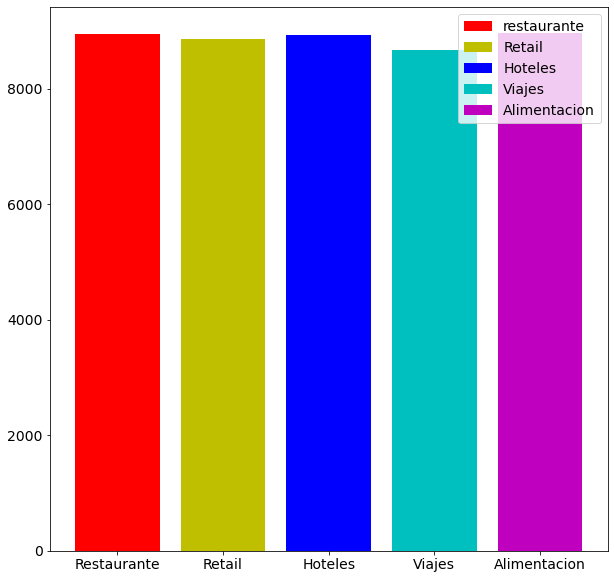

```python
fig, ma=plt.subplots()

ma.bar('Restaurante', sum(restaurante.values()), label='restaurante', color='r')
ma.bar('Retail', sum(retail.values()), label='Retail', color='y')
ma.bar('Hoteles',sum(hoteles.values()) , label='Hoteles', color='b')
ma.bar('Viajes', sum(viajes.values()), label='Viajes', color='c')
ma.bar('Alimentacion', sum(alimentaciones.values()), label='Alimentacion', color='m')

ma.legend()
```

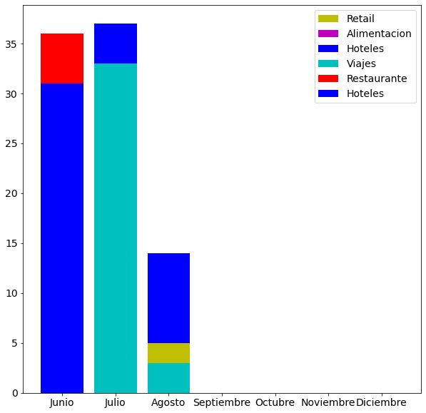

```python
fig, ma=plt.subplots()


ma.bar('Junio', sum(rj), label='Retail', color='y')
ma.bar('Junio', sum(alj), label='Alimentacion', color='m')
ma.bar('Junio',sum(hj) , label='Hoteles', color='b')
ma.bar('Junio', sum(vj), label='Viajes', color='c')
ma.bar('Junio', sum(rj), label='Restaurante', color='r')
ma.bar('Junio',sum(hj) , label='Hoteles', color='b')


ma.bar('Julio', sum(rju), label='', color='r')
ma.bar('Julio', sum(rju), label='', color='y')
ma.bar('Julio', sum(alju), label='', color='m')
ma.bar('Julio',sum(hju) , label='', color='b')
ma.bar('Julio', sum(vju), label='', color='c')

ma.bar('Agosto',sum(ha) , label='', color='b')
ma.bar('Agosto', sum(ala), label='', color='m')
ma.bar('Agosto', sum(ra), label='', color='r')
ma.bar('Agosto', sum(ra), label='', color='y')
ma.bar('Agosto', sum(va), label='', color='c')

ma.bar('Septiembre', sum(als), label='', color='m')
ma.bar('Septiembre', sum(rs), label='', color='r')
ma.bar('Septiembre',sum(hs) , label='', color='b')
ma.bar('Septiembre', sum(vs), label='', color='c')
ma.bar('Septiembre', sum(rs), label='', color='y')

ma.bar('Octubre', sum(alo), label='', color='m')
ma.bar('Octubre', sum(ro), label='', color='r')
ma.bar('Octubre',sum(ho) , label='', color='b')
ma.bar('Octubre', sum(vo), label='', color='c')
ma.bar('Octubre', sum(ro), label='', color='y')

ma.bar('Noviembre', sum(aln), label='', color='m')
ma.bar('Noviembre', sum(rn), label='', color='r')
ma.bar('Noviembre',sum(hn) , label='', color='b')
ma.bar('Noviembre', sum(vn), label='', color='c')
ma.bar('Noviembre', sum(rn), label='', color='y')

ma.bar('Diciembre', sum(ald), label='', color='m')
ma.bar('Diciembre', sum(rd), label='', color='r')
ma.bar('Diciembre',sum(hd) , label='', color='b')
ma.bar('Diciembre', sum(vd), label='', color='c')
ma.bar('Diciembre', sum(rd), label='', color='y')

ma.legend()
```

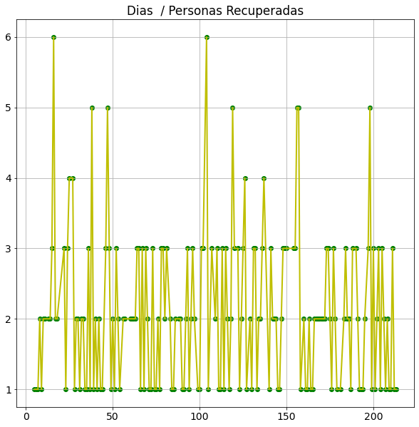

```python
recu=sorted(recuperados.items())
x,y=zip(*recu)
plt.plot(x,y,linewidth=2,color='y')
plt.scatter(x,y,color='g')
plt.title("Dias  / Personas Recuperadas")
plt.grid(True)
plt.show()
```

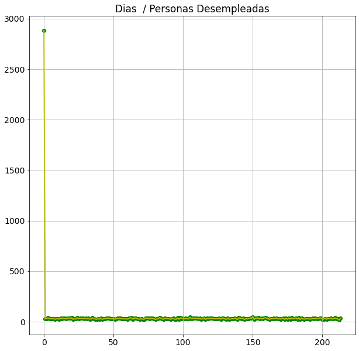

```python
recu=sorted(desempleados.items())
x,y=zip(*recu)
plt.plot(x,y,linewidth=2,color='y')
plt.scatter(x,y,color='g')
plt.title("Dias  / Personas Desempleadas")
plt.grid(True)
plt.show()
```

# **Conclusiones**

• Cual tiene una mejor prediccion. • Ventajas y desventajas de los modelos. • Comparacion entre los modelos aplicados.

El modelo Polinomial, se trata de un modelo lineal en el que se incorporan nuevos predictores elevando el valor de los casos ya existentes a diferentes potencias. por lo que un polinomio de cuarto grado podría capturar mejor la relación entre las variables. Los pronósticos probabilísticos pueden aplicarse a muchos ámbitos, que van desde el pronóstico del tiempo hasta las apuestas deportivas, pero son especialmente útiles para la optimización de la cadena de suministro. Desde mi punto de vista, el modelo que realiza la mejor predicción es probabilístico, ya que se ajusta más a lo que esta pasando en el país.

### Ventajas y desventajas

*Ventajas*  
Nos permiten predecir como va creciento la tasa de contagiados en esta Proviencia. Requieren menos tiempo y es menos caro que experimentar con el objeto o la situación real. Permiten una identificación rápida de las expectativas esperadas Reducen los riesgos asociados con la experimentación real

*Desventajas*  
Por el número de contagiados y tomando en cuenta que no son datos precisos no se puede tener una precision a futuro correcta. Se pierde información (que puede ser relevante) del fenómeno que se esta estudiando. Las diferentes interpretaciones de la información, pueden ocasionar resultados que estén lejos de la realidad. La recolección de datos puede ser muy costosa y complicada. Sensibilidad ante errores de medición; a veces pequeñas variaciones en los datos ocasionan que se tengan resultados opuestos

**Rerefencias** https://www.primicias.ec/noticias/sociedad/laboratorios-autorizados-pruebas-covid-ecuador/